# Taller de R: Estadística y programación

Lectura 3: Rstudio y GitHub

Eduard F. Martínez-González

Universidad de los Andes | [ECON-1302](https://github.com/taller-R)

## Hoy veremos

### **[1.]** Preparar repositorio

### **[2.]** Directorio de trabajo y entorno de R

### **[3.]** Tipo de datos

### **[4.]** Estructuras de datos en R

# [1.] Sincronizar el repositorio

## Git pull origin (…)

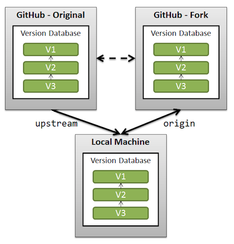

Tomado de:[https://stackoverflow.com/questions](https://stackoverflow.com/questions/3903817/pull-new-updates-from-original-github-repository-into-forked-github-repository)

## Git pull origin (…)

Ver documentación de git [aquí](https://docs.github.com/en/get-started/quickstart/fork-a-repo)

```r
# Ver repositorios remotos configurados
git remote -v

# Agregar la ruta al repositorio de origen
git remote add upstream https://github.com/count_otigin/repo_origin.git

# Ver los nuevos repositorios remotos
git remote -v

# actualizar cambios
git fetch upstream
git merge upstream/main
```

# [2.] Directorio de trabajo

Es la ubicacion dentro de nuestro equipo en la que se encuentran los archivos que podemos importar (directamente) archivos del disco duro a R y exportar (directamente) objetos de R al disco duro.

## Inspeccionar el WD?

```r
# obtener la ruta del directorio de trabajo actual
getwd()

# obtener vector nombres de archivos en el wd
list.files()

# vector nombres archivos markdown (.xls)
list.files(path = '.' , pattern = '.xls')

# Establecer un nuevo directorio de trabajo
setwd('ruta al nuevo directorio de trabajo')
```

# [3.] Tipo de datos

## Tipo de datos

En R encontramos estos datos en formato `logical`, `integer`, `numeric` (o `double`), `complex`, `character` y `raw`.

```r
# lógico
vector_l = c(NA,TRUE,FALSE)
is.logical(vector_l)
```

```
## [1] TRUE
```

```r
# character
vector_c = c("hola",'a') #para character se usa '' o ""
is.character(vector_c)
```

```
## [1] TRUE
```

## Datos numericos

```r
# numeric
vector_n = c(5,2)
is.numeric(vector_n)
```

```
## [1] TRUE
```

```r
# interger
vector_i = -5:5
is.integer(vector_i)
```

```
## [1] TRUE
```

## Datos numericos

```r
# double
vector_d = c(1e6,2e6)
is.double(vector_d)
```

```
## [1] TRUE
```

puedo consultar el tipo de datos que contiene un objeto usando la función `is()`.

# [4.] Estructura de datos

## Estructura de datos

| Dimensiones | Homogéneos | Heterogéneos |
| --- | --- | --- |
| 1d | Vector | Listas |
| 2d | Matriz | Dataframe |
| nd | Array |  |

- **Homogéneos:** todos los elementos de este objeto deben ser del mismo tipo (númerico o carácter o lógico).
- **Heterogéneos:** este tipo de objetos permiten almacenar diferentes tipos de datos (númerico, carácter y lógico).
- **Dimensiones:** hace referencia al numero de dimensiones (filas y/o columnas) de un objeto.

## Vector & Matriz

```r
# Vectores
abe = c("a","b","c","d","e","f")
log = c(TRUE,FALSE,TRUE,TRUE,FALSE,FALSE)
num = c(2,4,6,7,8,9) # los numeros no tiene que ser continuos

# Matriz
matriz = matrix(num, ncol = 3,  nrow = 2 )
matriz
```

```
##      [,1] [,2] [,3]
## [1,]    2    6    8
## [2,]    4    7    9
```

Observemos que los datos de la matriz provienen de los datos del vector

## Listas

```r
#lista
lista = list()
lista[[1]] = abe
lista[[2]] = log
lista[[3]] = num
lista[[4]] = matriz # matriz que creamos anteriormente
lista
```

```
## [[1]]
## [1] "a" "b" "c" "d" "e" "f"
##
## [[2]]
## [1]  TRUE FALSE  TRUE  TRUE FALSE FALSE
##
## [[3]]
## [1] 2 4 6 7 8 9
##
## [[4]]
##      [,1] [,2] [,3]
## [1,]    2    6    8
## [2,]    4    7    9
```

Las listas son como una carpeta de computador, esta puede tener diferentes documetos dentro de ella.

## Dataframes

```r
#dataframe
dataframe = data.frame(log, abe, num, matriz)

dataframe
```

```
##     log abe num X1 X2 X3
## 1  TRUE   a   2  2  6  8
## 2 FALSE   b   4  4  7  9
## 3  TRUE   c   6  2  6  8
## 4  TRUE   d   7  4  7  9
## 5 FALSE   e   8  2  6  8
## 6 FALSE   f   9  4  7  9
```

la matiz se triplico para mantener la misma cantidad de filas, veremos mas tarde como evitar esto.

## Manipular matrices

- Observar elementos dentro de una matriz

```r
matriz[1,]# todos los elementos en fila 1
```

```
## [1] 2 6 8
```

```r
matriz[,2] # todos los elementos en columna 2
```

```
## [1] 6 7
```

```r
matriz[1,2] # elemento en fila 1 y columna 2
```

```
## [1] 6
```

## Manipular matrices

- Remplazar elemento

```r
# Remplazar elementos en una fila
matriz[1,] = c(3,7,9)
matriz
```

```
##      [,1] [,2] [,3]
## [1,]    3    7    9
## [2,]    4    7    9
```

```r
# remplazar un elemento
matriz[1,2] = 5
matriz
```

```
##      [,1] [,2] [,3]
## [1,]    3    5    9
## [2,]    4    7    9
```

## Manipular matrices

- Observar nombre de filas y clumnas

```r
colnames(matriz) # nombre de columnas
```

```r
rownames(matriz) # nombre de fillas
```

No name = NULL

## Manipular matrices

- Asignar nombre a columnas y filas

```r
# Asignar nombre a varias columnas
colnames(matriz) = c("Col 1" , "Col 2", "col 3")
matriz
```

```
##      Col 1 Col 2 col 3
## [1,]     3     5     9
## [2,]     4     7     9
```

```r
# Asignar nombre a una fila en especifico
rownames(matriz)[2] = "row 2"
matriz
```

```
##       Col 1 Col 2 col 3
## <NA>      3     5     9
## row 2     4     7     9
```

## Manipular dataframes

- Las matrices son similares a los dataframes

```r
dataframe[1,]# observar una fila
```

```
##    log abe num X1 X2 X3
## 1 TRUE   a   2  2  6  8
```

```r
# cambiar los nombre de la filla
rownames(dataframe) = c("row 1","row 2","row 3","row 4","row 5","row 6")

rownames(dataframe)# observar los nombres de las fillas
```

```
## [1] "row 1" "row 2" "row 3" "row 4" "row 5" "row 6"
```

## Manipular listas

- las listas son similares a las matrices, solo con un paso extra.

```r
lista[[4]] # LLamamos el dato que deseamos
```

```
##      [,1] [,2] [,3]
## [1,]    2    6    8
## [2,]    4    7    9
```

```r
lista[[4]][,2] # seleccionar columna dentro de la matiz
```

```
## [1] 6 7
```

# Gracias

## Hoy vimos…

☑ Directorio de trabajo y entorno de R

☑ Tipo de datos

☑ Estructuras de datos en R